# planningML User Guide

Xinying Fang

2022-11-06

## Introduction

Advances in automated document classification has led to identifying massive numbers of clinical concepts from handwritten clinical notes. These high dimensional clinical concepts can serve as highly informative predictors in building classification algorithms for identifying patients with different clinical conditions, commonly referred to as patient phenotyping. However, from a planning perspective, it is critical to ensure that enough data is available for the phenotyping algorithm to obtain a desired classification performance. This challenge in sample size planning is further exacerbated by the high dimensionality of the feature space and the inherent imbalance of the response class. Currently available sample size planning methods can be categorized into: (i) model-based approaches that predict the sample size required for achieving a desired accuracy using a linear machine learning classifier and (ii) learning curve-based approaches that fit an inverse power law curve to pilot data to extrapolate performance. We develop model-based approaches for imbalanced data with correlated features, deriving sample size formulas for performance metrics that are sensitive to class imbalance such as Area Under the receiver operating characteristic Curve (AUC) and Matthews Correlation Coefficient (MCC). This is done using a two-step approach where we first perform feature selection using the innovated High Criticism thresholding method, then determine the sample size by optimizing the two performance metrics. Further, we develop software in the form of an R package named ‘planningML’ and an R Shiny app to facilitate the convenient implementation of the developed model-based approaches and learning curve approaches for imbalanced data. We apply our methods to the problem of phenotyping rare outcomes using the MIMIC-III electronic health record database. We show that our developed methods which relate training data size and performance on AUC and MCC, can predict the true or observed performance from linear ML classifiers such as LASSO and SVM at different training data sizes. Therefore, in high-dimensional classification analysis with imbalanced data and correlated features, our approach can efficiently and accurately determine the sample size needed for machine-learning based classification.

## Step 1: High dimentional feature selection

We consider the two-class classification problem with the high dimensional covariate vector $x \sim N(\mu,\Sigma)$ when $x \in C_1$ and $x \sim N(-\mu,\Sigma)$ when $x \in C_2$. Using LDA classify$x \in C_1$ when $2 \boldsymbol {x^T\Sigma^{-1}\mu>k}$ where $k>log(\frac{1-p_1}{p_1})$ Given the high-dimensionality of the feature space we employ a feature selection procedure to eliminate $(p-m)$ redundant covariates, hence making $\Sigma$ non-singular. Only the remaining $m$ features are included in the linear classifier. HCT method employs Higher Criticism Thresholding2 approach to select m important features out of the p total features

iHCT method improves the HCT method in a transformed coordinate system.

## Step 2: Computation of sample size dependent performance metrics

Once obtaining the $m$ important features, performance accuracy metrics that are sensitive to imbalanced class datasets are derived under both the DS and HCT method

$$where$$
$$\begin{align*}
TPR(n) &= E_w [P(w'x > \kappa| w,x \in C_1]\\
&\approx \Phi\bigg( \frac{\delta m (1- \beta) - \kappa}{\sigma
\sqrt{\rho} \sqrt{m (1- \beta) + (p-m) \alpha }}\bigg)\nonumber\\
TNR(n) &= E_w [P(w'x < \kappa| w,x \in C_2]\\
&\approx \Phi\bigg( \frac{\kappa + \delta m (1- \beta)}{\sigma
\sqrt{\rho} \sqrt{m (1- \beta) + (p-m) \alpha }}\bigg)
\end{align*}$$

$$
$$\begin{align*}
\text{PPV(n)} \approx
\frac{\pi_1 \times \Phi\bigg( \frac{\delta m (1- \beta) -
\kappa}{\sigma \sqrt{\rho} \sqrt{m (1- \beta) + (p-m) \alpha
}}\bigg)}{\pi_1 \times \Phi\bigg( \frac{\delta m (1- \beta) -
\kappa}{\sigma \sqrt{\rho} \sqrt{m (1- \beta) + (p-m) \alpha }}\bigg) +
\pi_2 \times \bigg\{ 1- \Phi\bigg( \frac{\kappa + \delta m (1-
\beta)}{\sigma \sqrt{\rho} \sqrt{m (1- \beta) + (p-m) \alpha }}\bigg)
\bigg\}}
\end{align*}$$

$$\begin{align*}
\text{NPV(n)} &= \approx
\frac{\pi_2 \times \Phi\bigg( \frac{\delta m (1- \beta) +
\kappa}{\sigma \sqrt{\rho} \sqrt{m (1- \beta) + (p-m) \alpha }}\bigg)
}{\pi_2 \times \Phi\bigg( \frac{\delta m (1- \beta) + \kappa}{\sigma
\sqrt{\rho} \sqrt{m (1- \beta) + (p-m) \alpha }}\bigg) + \pi_1 \times
\Phi\bigg( \frac{\delta m (1- \beta) - \kappa}{\sigma \sqrt{\rho}
\sqrt{m (1- \beta) + (p-m) \alpha }}\bigg) }
\end{align*}$$

## Example: Sample size determination for identifying patients with Depression in MIMIC-III database

Clinical notes were extracted from the MIMIC-III database which contains de-identified clinical data of over 53,000 hospital admissions for adult patients to the intensive care units (ICU) at the Beth Israel Deaconess Medical Center from 2001 to 2012. This project uses a dataset of 833 patient discharge summaries restricted to frequently re-admitted patients (>3 in a single year), labeled with 15 clinical patient phenotypes believed to be associated with risk of recurrent readmission by domain experts.

The example was focused on building a classifier for identifying patients with ‘Depression’, which had a prevalence of 29%. Clinical notes were transformed into Unified Medical Language System (UMLS) Concepts using MetaMap Lite. Each note represented as a vector of 10,109 Concept Unique Identifiers (CUIs). A pilot dataset comprising 135 samples was used to determine the optimal sample size.

```r
## load dataset
pilot.data = readRDS(system.file("extdata", "pilotdata.rds", package = "planningML"))
dim(pilot.data)
```

```
#> [1]   135 10109
```

```r
x = pilot.data[,-ncol(pilot.data)]
y = pilot.data$DEPRESSION
```

```r
head(x)
```

[output not shown]

[output cut: 9827 more lines]

```r
y
```

```
#>   [1] 0 0 0 0 0 0 0 0 0 0 1 1 0 0 1 0 1 0 0 0 1 0 0 1 0 0 0 1 0 0 0 1 0 1 0 0 0
#>  [38] 0 1 0 0 0 0 0 0 0 0 0 0 1 1 1 1 0 0 1 0 0 0 0 0 1 0 0 0 0 0 0 0 1 0 0 1 0
#>  [75] 0 0 0 0 0 1 1 0 0 0 0 0 0 0 0 0 0 0 0 0 0 0 0 0 0 0 0 0 0 0 1 0 0 1 0 0 0
#> [112] 1 0 0 0 1 1 0 0 0 1 0 0 0 0 0 1 1 1 0 1 0 0 0 0
```

### Feature selection based on iHCT method

```r
library(planningML)
```

```r
features = featureselection(x = x, y = y)
```

```r
summary(features)
```

```
#> The selected important features are (ranked by importance):
#>   [1] "C0308718" "C0242209" "C2062441" "C1707759" "C1553114" "C0005800"
#>   [7] "C0024476" "C0770694" "C0209210" "C0071315" "C1833247" "C4036057"
#>  [13] "C0187970" "C1304878" "C3665462" "C0718050" "C0746940" "C3811910"
#>  [19] "C0011946" "C4551529" "C4554649" "C0085681" "C4288280" "C3845187"
#>  [25] "C3829424" "C0004147" "C1142423" "C4722408" "C3827898" "C0281788"
#>  [31] "C0457097" "C4082832" "C2984924" "C1704536" "C0005771" "C0184633"
#>  [37] "C0849974" "C0748355" "C4553976" "C0085606" "C3841902" "C0427760"
#>  [43] "C0086439" "C2059391" "C0546959" "C0425687" "C3537249" "C0042866"
#>  [49] "C1135194" "C0751534" "C0376196" "C0242401" "C0221793" "C0032768"
#>  [55] "C0013428" "C4553955" "C0041912" "C4520849" "C4553188" "C4554644"
#>  [61] "C0036412" "C0036410" "C1553116" "C0008913" "C0721336" "C1837655"
#>  [67] "C0014695" "C0425245" "C0086143" "C0454527" "C0011854" "C0199782"
#>  [73] "C0392806" "C0721062" "C0666743" "C1154231" "C0036202" "C0887128"
#>  [79] "C2973725" "C0142825" "C2697310" "C0665820" "C0411881" "C0201956"
```

[output cut: 24 more lines]

### Sample size determination

```r
output = samplesize(features=features,
                    method="HCT", m=c(5,10,length(features$features)), effectsize=NULL,
                    class.prob = NULL, totalnum_features = NULL, threshold=0.1, metric="MCC")
head(output$outtable)
```

```
#>                m = 5      m = 10    m = 224
#> n = 10  0.0004470932 0.001232158 0.01494497
#> n = 30  0.0009805297 0.003115510 0.03721976
#> n = 50  0.0016525732 0.005540793 0.06395991
#> n = 70  0.0022315595 0.008293054 0.08659051
#> n = 90  0.0030325605 0.010975638 0.11602953
#> n = 110 0.0039033601 0.013273915 0.13786869
```

The minimum sample sizes needed under different number of selected important features are:

```r
summary(output)
```

```
#> The minimum sample size(s) are:
#>   m = 5  m = 10 m = 224
#>      10     550     570
```

A plot demonstrating the relationship between sample size the performance measurement metrics are demonstrated:

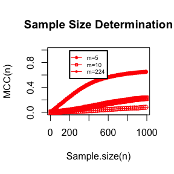

```r
plot(output)
```

#### Skip the featureselection step for iHCT method

For the iHCT method, if we have historical information and want to skip the featureselection step, then we can supply the number of important features (m), effect size (sample mean difference), prevalence of the event (class.prob), and total number of features (totalnum_features) and obtain an estimation of the optimal sample size.

```r
effect_size = readRDS(system.file("extdata", "effectsize.rds", package = "planningML"))
effect_size
```

```
#>     C0308718     C0242209     C2062441     C1707759     C1553114     C0005800
#> 0.0532284013 0.0035848214 0.3872983346 0.3872983346 0.3872983346 0.3872983346
#>     C0024476     C0770694     C0209210     C0071315     C1833247     C4036057
#> 0.3872983346 0.3872983346 0.3872983346 0.3872983346 0.3872983346 0.1642136970
#>     C0187970     C1304878     C3665462     C0718050     C0746940     C3811910
#> 0.1680808526 0.1680808526 0.0907053977 0.0785280272 0.5492792713 0.0359758836
#>     C0011946     C4551529     C4554649     C0085681     C4288280     C3845187
#> 0.2349100912 0.2349100912 0.1280136797 0.1280136797 0.1280136797 0.0979354038
#>     C3829424     C0004147     C1142423     C4722408     C3827898     C0281788
#> 0.0789538906 0.0958983493 0.1351587911 0.1116121177 0.3872983346 0.3872983346
#>     C0457097     C4082832     C2984924     C1704536     C0005771     C0184633
#> 0.3872983346 0.3872983346 0.3872983346 0.3872983346 0.3872983346 0.1069155896
#>     C0849974     C0748355     C4553976     C0085606     C3841902     C0427760
#> 0.0186034176 0.3872983346 0.3872983346 0.3872983346 0.3872983346 0.3872983346
#>     C0086439     C2059391     C0546959     C0425687     C3537249     C0042866
#> 0.0641800948 0.4623815612 0.4623815612 0.3904595333 0.2708097814 0.2708097814
#>     C1135194     C0751534     C0376196     C0242401     C0221793     C0032768
#> 0.1706327035 0.1114210172 0.1153205801 0.1153205801 0.1153205801 0.4789845658
#>     C0013428     C4553955     C0041912     C4520849     C4553188     C4554644
#> 0.0806712006 0.0806712006 0.1921783699 0.1013465479 0.0005357778 0.0542465901
#>     C0036412     C0036410     C1553116     C0008913     C0721336     C1837655
#> 0.0013319962 0.0013319962 0.1412869273 0.5369385741 0.0849364616 0.4627718668
#>     C0014695     C0425245     C0086143     C0454527     C0011854     C0199782
#> 0.2904485537 0.2231914239 0.2039506981 0.6240148447 0.1911446452 0.5308303973
#>     C0392806     C0721062     C0666743     C1154231     C0036202     C0887128
#> 0.1889024795 0.1045466673 0.1045466673 0.3872983346 0.3872983346 0.3872983346
#>     C2973725     C0142825     C2697310     C0665820     C0411881     C0201956
#> 0.3872983346 0.3872983346 0.3872983346 0.3872983346 0.3872983346 0.3872983346
#>     C0055819     C0333297     C0947205     C4554630     C0425619     C4050122
#> 0.3872983346 0.3872983346 0.3872983346 0.2557591477 0.5496375042 0.1308123531
#>     C0524151     C0012306     C0038354     C3538993     C0003873     C0018790
#> 0.3678869753 0.3678869753 0.2458432894 0.1271418666 0.1416750983 0.1427616239
#>     C0020616     C3842089     C0032617     C0699749     C0886384     C0003484
#> 0.1362370984 0.1828998662 0.1064430913 0.0230964094 0.0376937602 0.1825409094
#>     C0439775     C0598322     C0022209     C3887695     C0245203     C4028269
#> 0.4289408662 0.3006151131 0.3006151131 0.0152635988 0.0152635988 0.2379113427
#>     C0079304     C4552833     C0593906     C0004623     C4551916     C0020550
#> 0.3972306323 0.2132084732 0.0054080980 0.0844944670 0.0410797997 0.0410797997
#>     C0038826     C1963211     C3539032     C0037090     C0232285     C0006699
#> 0.3872983346 0.3872983346 0.3872983346 0.3872983346 0.3872983346 0.3872983346
```

[output cut: 21 more lines]

```
#> 0.0336974206 0.3006099939 0.2621825595 0.3342841983 0.1570759882 0.4194609108
#>     C0151785     C4553925     C0199451     C0700444     C0699690     C0027415
#> 0.2335850866 0.2208730499 0.4259050612 0.1561967247 0.1561967247 0.1593081209
#>     C0006462     C0230461     C1947952     C0193842     C0025148     C0028013
#> 0.1668006522 0.1759405280 0.3872983346 0.3872983346 0.3872983346 0.3872983346
#>     C4054523     C0023928     C0521377     C0025065     C0019079     C0230442
#> 0.3872983346 0.3872983346 0.3872983346 0.3872983346 0.0960619403 0.0061075115
#>     C0028643     C4552662     C0578671     C0007286     C1568891     C0026267
#> 0.0655732973 0.1064271438 0.0911480028 0.1490643598 0.1765441108 0.3587805055
#>     C0018563     C0225594     C3844350     C0037303     C0229187     C0004096
#> 0.0843152950 0.4722282595 0.1563914610 0.1428049773 0.1472303233 0.1148448657
#>     C0349790     C1511237     C0751781     C1412000     C0497247     C0524002
#> 0.1373342666 0.1991077645 0.2186758579 0.1429955793 0.1425967205 0.0988100974
#>     C0002333     C0009437
#> 0.0988100974 0.1717292383
```

```r
output2 = samplesize(features = NULL,
                      method="HCT", m=200, effectsize=effect_size, class.prob = 0.5,
                     totalnum_features = 5000, threshold=0.1, metric="MCC")
```

```r
summary(output2)
```

```
#> The minimum sample size(s) are:
#> m = 200
#>     430
```

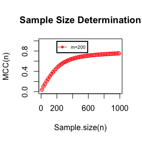

```r
plot(output2)
```

## Learning curve approximation method for imbalanced data

The learning curve approximation method is demonstrated with the 2016 National Hospital Ambulatory Medical Care Survey (NHAMCS) data. The NHAMCS data examined factors associated with opioid prescriptions in the emergency department. The outcome variable is receipt of opioid prescription, and the primary variable of interest was the type of visit (dental/non-dental) with other features including age, gender, race/ethnicity, region, payer, day of the visit, and pain level.

The input NHAMCS dataset has been pre-processed for convenient analysis. We will use the part of the NHAMCS dataset as the pilot data to build the learning curve.

```r
pilotSet = readRDS(system.file("extdata", "pilotSet.rds", package = "planningML"))
pilotY = readRDS(system.file("extdata", "pilotY.rds", package = "planningML"))
```

```r
dim(pilotSet)
```

```
#> [1] 2007  248
```

```r
table(pilotY)
```

```
#> pilotY
#>    1    0
#>  191 1816
```

### Obtain fitted data to build the learning curve

```r
nhamcs_rf_auc <- learningcurve_data(pilotSet, pilotY, method="rf", batchsize = 100, nfold=5, nrepeat=10, class.prob = 0.105, metric="AUC")
```

```r
nhamcs_rf_auc
```

```
#>    Sample size       AUC
#> 1          100 0.5391040
#> 2          200 0.5581847
#> 3          300 0.5899159
#> 4          400 0.5971691
#> 5          500 0.6198891
#> 6          600 0.6461288
#> 7          700 0.6680839
#> 8          800 0.7104647
#> 9          900 0.7107402
#> 10        1000 0.7065173
#> 11        1100 0.7592866
#> 12        1200 0.7596999
#> 13        1300 0.7702262
#> 14        1400 0.8231332
#> 15        1500 0.7618421
#> 16        1600 0.8513158
```

### Fit learning curve

With the learning curve dataset, we can fit the learning curve:

```r
lc_fit <- fit_learningcurve(nhamcs_rf_auc, testX=seq(10, 1500, 5), target=0.8)
```

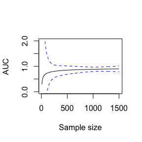

```r
plot(lc_fit)
```